# DATS 6103 - Individual Project 1 - Jesse Borg

## Introduction

This project will anaylse military spending, along with other data such as GDP, GDP Per Capita and population for the United States, China, Russia, Germany, United Kingdom, France, Italy, Saudi Arabia, South Korea and Australia between the years of 2013 and 2018.

The aim of this project is to find patterns, correlations and gather enough information to be able to make predictions about future trends.

Since a lot of data was required for this analysis, the best place to obtain the required data sets was from the worldbank data bank (https://data.worldbank.org/), where they were readily available to download. Once the data was downloaded as CSV files, the cleaning process could begin so that the analysis could yield accurate and meaningful results.

## Cleaning Process

Since multiple datasets are going to be used for this analysis, the best way to approach this is to initially read each CSV file while setting the country name as the index, which will be kept constant across all datasets. Then, the unwanted countries and years will be removed so that what is left is the relevant information, as mentioned above. To make it easier to concatenate the datasets, each individual one will be stacked according to the Country; this will make the data easy to read in one big dataframe and will also facilitate the plotting of data over a number of years for the different datasets.

Once this has been completed, the data can then be plotted in various ways to make it easy to observe changes over time, patterns or any correlations that may exist. Below, this cleaning process was carried out and then the resulting dataframe was used to plot the desired data.

```python
# Import the required tools from the Python library and then abbreviate them to make it easier and quicker to call upon when needed
import pandas as pd
import matplotlib.pyplot as plt
from IPython.display import display
```

```python
# Import each dataset using the Pandas library, giving them appropriate names and setting the country name as the index
# Check to see if the data was read correctly for each data set by using the df.head() function
gdp = pd.read_csv('gdp.csv', index_col = 0)
gdp.head()
```

| Country Name | Country Code | Indicator Name | Indicator Code | 1960 | 1961 | 1962 | 1963 | 1964 | 1965 | 1966 | ... | 2009 | 2010 | 2011 | 2012 | 2013 | 2014 | 2015 | 2016 | 2017 | 2018 |
| --- | --- | --- | --- | --- | --- | --- | --- | --- | --- | --- | --- | --- | --- | --- | --- | --- | --- | --- | --- | --- | --- |
| Aruba | ABW | GDP (current US$) | NY.GDP.MKTP.CD | NaN | NaN | NaN | NaN | NaN | NaN | NaN | ... | 2.498883e+09 | 2.390503e+09 | 2.549721e+09 | 2.534637e+09 | 2.581564e+09 | 2.649721e+09 | 2.691620e+09 | 2.646927e+09 | 2.700559e+09 | NaN |
| Afghanistan | AFG | GDP (current US$) | NY.GDP.MKTP.CD | 537777811.1 | 548888895.6 | 546666677.8 | 751111191.1 | 800000044.4 | 1.006667e+09 | 1.400000e+09 | ... | 1.243909e+10 | 1.585657e+10 | 1.780428e+10 | 2.000162e+10 | 2.056105e+10 | 2.048487e+10 | 1.990711e+10 | 1.936264e+10 | 2.019176e+10 | 1.936297e+10 |
| Angola | AGO | GDP (current US$) | NY.GDP.MKTP.CD | NaN | NaN | NaN | NaN | NaN | NaN | NaN | ... | 7.030716e+10 | 8.379950e+10 | 1.120000e+11 | 1.280000e+11 | 1.370000e+11 | 1.460000e+11 | 1.160000e+11 | 1.010000e+11 | 1.220000e+11 | 1.060000e+11 |
| Albania | ALB | GDP (current US$) | NY.GDP.MKTP.CD | NaN | NaN | NaN | NaN | NaN | NaN | NaN | ... | 1.204421e+10 | 1.192695e+10 | 1.289087e+10 | 1.231978e+10 | 1.277628e+10 | 1.322825e+10 | 1.138693e+10 | 1.186135e+10 | 1.302506e+10 | 1.505888e+10 |
| Andorra | AND | GDP (current US$) | NY.GDP.MKTP.CD | NaN | NaN | NaN | NaN | NaN | NaN | NaN | ... | 3.660531e+09 | 3.355695e+09 | 3.442063e+09 | 3.164615e+09 | 3.281585e+09 | 3.350736e+09 | 2.811489e+09 | 2.877312e+09 | 3.013387e+09 | 3.236544e+09 |

5 rows × 62 columns

```python
percapita = pd.read_csv('percapita.csv', index_col = 0)
percapita.head()
```

| Country Name | Country Code | Indicator Name | Indicator Code | 1960 | 1961 | 1962 | 1963 | 1964 | 1965 | 1966 | ... | 2009 | 2010 | 2011 | 2012 | 2013 | 2014 | 2015 | 2016 | 2017 | 2018 |
| --- | --- | --- | --- | --- | --- | --- | --- | --- | --- | --- | --- | --- | --- | --- | --- | --- | --- | --- | --- | --- | --- |
| Aruba | ABW | GDP per capita (current US$) | NY.GDP.PCAP.CD | NaN | NaN | NaN | NaN | NaN | NaN | NaN | ... | 24630.453710 | 23512.602600 | 24985.993280 | 24713.698050 | 25025.099560 | 25533.569780 | 25796.380250 | 25239.600410 | 25630.266490 | NaN |
| Afghanistan | AFG | GDP per capita (current US$) | NY.GDP.PCAP.CD | 59.773194 | 59.860874 | 58.458015 | 78.706388 | 82.095231 | 101.108305 | 137.594352 | ... | 438.076034 | 543.303042 | 591.162347 | 641.872034 | 637.165044 | 613.856333 | 578.466353 | 547.228110 | 556.302138 | 520.896603 |
| Angola | AGO | GDP per capita (current US$) | NY.GDP.PCAP.CD | NaN | NaN | NaN | NaN | NaN | NaN | NaN | ... | 3122.780766 | 3587.883798 | 4615.468028 | 5100.095808 | 5254.882338 | 5408.410496 | 4166.979684 | 3506.072885 | 4095.812942 | 3432.385736 |
| Albania | ALB | GDP per capita (current US$) | NY.GDP.PCAP.CD | NaN | NaN | NaN | NaN | NaN | NaN | NaN | ... | 4114.134899 | 4094.358816 | 4437.177794 | 4247.614342 | 4413.082887 | 4578.667934 | 3952.830781 | 4124.108543 | 4532.889198 | 5253.630064 |
| Andorra | AND | GDP per capita (current US$) | NY.GDP.PCAP.CD | NaN | NaN | NaN | NaN | NaN | NaN | NaN | ... | 43338.866760 | 39736.354060 | 41100.729940 | 38392.943900 | 40626.751630 | 42300.334130 | 36039.653500 | 37224.108920 | 39134.393370 | 42029.762740 |

5 rows × 62 columns

```python
population = pd.read_csv('population.csv', index_col = 0)
population.head()
```

| Country Name | Country Code | Indicator Name | Indicator Code | 1960 | 1961 | 1962 | 1963 | 1964 | 1965 | 1966 | ... | 2009 | 2010 | 2011 | 2012 | 2013 | 2014 | 2015 | 2016 | 2017 | 2018 |
| --- | --- | --- | --- | --- | --- | --- | --- | --- | --- | --- | --- | --- | --- | --- | --- | --- | --- | --- | --- | --- | --- |
| Aruba | ABW | Population, total | SP.POP.TOTL | 54211.0 | 55438.0 | 56225.0 | 56695.0 | 57032.0 | 57360.0 | 57715.0 | ... | 101455.0 | 101669.0 | 102046.0 | 102560.0 | 103159.0 | 103774.0 | 104341.0 | 104872.0 | 105366.0 | 105845.0 |
| Afghanistan | AFG | Population, total | SP.POP.TOTL | 8996973.0 | 9169410.0 | 9351441.0 | 9543205.0 | 9744781.0 | 9956320.0 | 10174836.0 | ... | 28394813.0 | 29185507.0 | 30117413.0 | 31161376.0 | 32269589.0 | 33370794.0 | 34413603.0 | 35383128.0 | 36296400.0 | 37172386.0 |
| Angola | AGO | Population, total | SP.POP.TOTL | 5454933.0 | 5531472.0 | 5608539.0 | 5679458.0 | 5735044.0 | 5770570.0 | 5781214.0 | ... | 22514281.0 | 23356246.0 | 24220661.0 | 25107931.0 | 26015780.0 | 26941779.0 | 27884381.0 | 28842484.0 | 29816748.0 | 30809762.0 |
| Albania | ALB | Population, total | SP.POP.TOTL | 1608800.0 | 1659800.0 | 1711319.0 | 1762621.0 | 1814135.0 | 1864791.0 | 1914573.0 | ... | 2927519.0 | 2913021.0 | 2905195.0 | 2900401.0 | 2895092.0 | 2889104.0 | 2880703.0 | 2876101.0 | 2873457.0 | 2866376.0 |
| Andorra | AND | Population, total | SP.POP.TOTL | 13411.0 | 14375.0 | 15370.0 | 16412.0 | 17469.0 | 18549.0 | 19647.0 | ... | 84463.0 | 84449.0 | 83747.0 | 82427.0 | 80774.0 | 79213.0 | 78011.0 | 77297.0 | 77001.0 | 77006.0 |

5 rows × 62 columns

```python
spending = pd.read_csv('spending.csv', index_col = 0)
spending.head()
```

| Country Name | Country Code | Indicator Name | Indicator Code | 1960 | 1961 | 1962 | 1963 | 1964 | 1965 | 1966 | ... | 2009 | 2010 | 2011 | 2012 | 2013 | 2014 | 2015 | 2016 | 2017 | 2018 |
| --- | --- | --- | --- | --- | --- | --- | --- | --- | --- | --- | --- | --- | --- | --- | --- | --- | --- | --- | --- | --- | --- |
| Aruba | ABW | Military expenditure (current USD) | MS.MIL.XPND.CD | NaN | NaN | NaN | NaN | NaN | NaN | NaN | ... | NaN | NaN | NaN | NaN | NaN | NaN | NaN | NaN | NaN | NaN |
| Afghanistan | AFG | Military expenditure (current USD) | MS.MIL.XPND.CD | NaN | NaN | NaN | NaN | NaN | NaN | NaN | ... | 2.518695e+08 | 2.981469e+08 | 3.258070e+08 | 2.385834e+08 | 2.171941e+08 | 2.682271e+08 | 1.995186e+08 | 1.858783e+08 | 1.914071e+08 | 1.980863e+08 |
| Angola | AGO | Military expenditure (current USD) | MS.MIL.XPND.CD | NaN | NaN | NaN | NaN | NaN | NaN | NaN | ... | 3.311193e+09 | 3.500795e+09 | 3.639496e+09 | 4.144635e+09 | 6.090752e+09 | 6.841864e+09 | 3.608299e+09 | 2.764055e+09 | 3.062873e+09 | 1.983614e+09 |
| Albania | ALB | Military expenditure (current USD) | MS.MIL.XPND.CD | NaN | NaN | NaN | NaN | NaN | NaN | NaN | ... | 1.827369e+08 | 1.858932e+08 | 1.970068e+08 | 1.832047e+08 | 1.800155e+08 | 1.781204e+08 | 1.323507e+08 | 1.308532e+08 | 1.443827e+08 | 1.804887e+08 |
| Andorra | AND | Military expenditure (current USD) | MS.MIL.XPND.CD | NaN | NaN | NaN | NaN | NaN | NaN | NaN | ... | NaN | NaN | NaN | NaN | NaN | NaN | NaN | NaN | NaN | NaN |

5 rows × 62 columns

```python
# For the datasets, choose the desired countries and years using the loc function and then overwriting the variable as a new dataset
# Stack this new dataset, using level = 0 as a parameter to keep the country name as the main index
# Display the stacked dataset to check if it has been done successfully
gdp = gdp.loc[['United States', 'China', 'Russian Federation', 'Germany', 'United Kingdom', 'France', 'Italy', 'Saudi Arabia', 'Korea, Rep.', 'Australia'], '2013':'2018']
gdp = gdp.stack(level = 0)
display(gdp.head())

# This was done for all other datasets below to prepare for the merging of datasets
```

```
Country Name
United States  2013    1.680000e+13
               2014    1.750000e+13
               2015    1.820000e+13
               2016    1.870000e+13
               2017    1.950000e+13
dtype: float64
```

```python
percapita = percapita.loc[['United States', 'China', 'Russian Federation', 'Germany', 'United Kingdom', 'France', 'Italy', 'Saudi Arabia', 'Korea, Rep.', 'Australia'], '2013':'2018']
percapita = percapita.stack(level =  0)
display(percapita.head())
```

```
Country Name
United States  2013    53106.90977
               2014    55032.95800
               2015    56803.47243
               2016    57904.20196
               2017    59927.92983
dtype: float64
```

```python
population = population.loc[['United States', 'China', 'Russian Federation', 'Germany', 'United Kingdom', 'France', 'Italy', 'Saudi Arabia', 'Korea, Rep.', 'Australia'], '2013':'2018']
population = population.stack(level = 0)
display(population.head())
```

```
Country Name
United States  2013    316057727.0
               2014    318386421.0
               2015    320742673.0
               2016    323071342.0
               2017    325147121.0
dtype: float64
```

```python
spending = spending.loc[['United States', 'China', 'Russian Federation', 'Germany', 'United Kingdom', 'France', 'Italy', 'Saudi Arabia', 'Korea, Rep.', 'Australia'], '2013':'2018']
spending = spending.stack(level = 0)
display(spending.head())
```

```
Country Name
United States  2013    6.397040e+11
               2014    6.099140e+11
               2015    5.961050e+11
               2016    6.001060e+11
               2017    6.058030e+11
dtype: float64
```

```python
# To merge the datasets, use the pandas concat function and specify the datasets to join and the axis parameter set to 1 to join by columns
countries = pd.concat([gdp, percapita, population, spending], axis = 1)
display(countries.head()) # Check whether it has been done successfully
```

| Country Name |  | 0 | 1 | 2 | 3 |
| --- | --- | --- | --- | --- | --- |
| United States | 2013 | 1.680000e+13 | 53106.90977 | 316057727.0 | 6.397040e+11 |
|  | 2014 | 1.750000e+13 | 55032.95800 | 318386421.0 | 6.099140e+11 |
|  | 2015 | 1.820000e+13 | 56803.47243 | 320742673.0 | 5.961050e+11 |
|  | 2016 | 1.870000e+13 | 57904.20196 | 323071342.0 | 6.001060e+11 |
|  | 2017 | 1.950000e+13 | 59927.92983 | 325147121.0 | 6.058030e+11 |

```python
# The different datasets have been merged as columns; with their names set as their column index. Rename the columns to the different dataset information using the -
#  - rename function and specifying the column index as they have no name.
countries.rename(columns={ countries.columns[0]: "GDP", countries.columns[1]:'Per Capita', countries.columns[2]:'Population', countries.columns[3]:'Military' }, inplace = True)

# Rename South Korea and Russia to make their names easier to type and reduce error
countries = countries.rename(index = {'Korea, Rep.':'South Korea', 'Russian Federation':'Russia'})
countries.loc[['South Korea', 'Russia'] , :] # Check to see if the renaming has worked
```

| Country Name |  | GDP | Per Capita | Population | Military |
| --- | --- | --- | --- | --- | --- |
| Russia | 2013 | 2.300000e+12 | 16007.089990 | 143506911.0 | 8.835290e+10 |
|  | 2014 | 2.060000e+12 | 14100.729100 | 143819666.0 | 8.469650e+10 |
|  | 2015 | 1.360000e+12 | 9313.787542 | 144096870.0 | 6.641871e+10 |
|  | 2016 | 1.280000e+12 | 8745.375116 | 144342396.0 | 6.924531e+10 |
|  | 2017 | 1.580000e+12 | 10750.587120 | 144496740.0 | 6.652730e+10 |
|  | 2018 | 1.660000e+12 | 11288.872440 | 144478050.0 | 6.138755e+10 |
| South Korea | 2013 | 1.310000e+12 | 25890.018670 | 50428893.0 | 3.431122e+10 |
|  | 2014 | 1.410000e+12 | 27811.366380 | 50746659.0 | 3.755233e+10 |
|  | 2015 | 1.380000e+12 | 27105.076230 | 51014947.0 | 3.657077e+10 |
|  | 2016 | 1.410000e+12 | 27608.247430 | 51245707.0 | 3.688528e+10 |
|  | 2017 | 1.530000e+12 | 29742.838860 | 51466201.0 | 3.917068e+10 |
|  | 2018 | 1.620000e+12 | 31362.751470 | 51635256.0 | 4.306997e+10 |

## Comparing the military data to that country’s GDP

```python
# Since the GDP values are much larger than military spending, they wont be comparable when plotted on the same graph
# To fix this, the values were scaled to make them easily comparable on the same graph
countries['GDP x (10^12)'] = countries['GDP'] / 1000000000000
countries['Military x (10^10)'] = countries['Military'] / 10000000000
countries.head()
```

| Country Name |  | GDP | Per Capita | Population | Military | GDP x (10^12) | Military x (10^10) |
| --- | --- | --- | --- | --- | --- | --- | --- |
| United States | 2013 | 1.680000e+13 | 53106.90977 | 316057727.0 | 6.397040e+11 | 16.8 | 63.9704 |
|  | 2014 | 1.750000e+13 | 55032.95800 | 318386421.0 | 6.099140e+11 | 17.5 | 60.9914 |
|  | 2015 | 1.820000e+13 | 56803.47243 | 320742673.0 | 5.961050e+11 | 18.2 | 59.6105 |
|  | 2016 | 1.870000e+13 | 57904.20196 | 323071342.0 | 6.001060e+11 | 18.7 | 60.0106 |
|  | 2017 | 1.950000e+13 | 59927.92983 | 325147121.0 | 6.058030e+11 | 19.5 | 60.5803 |

```python
# Create a function to plot graphs for a specified country and dataset
# This function will be used to plot GDP against Military spending, so the title and axis labels are set accordingly
# Setting the line labels to the pertinent dataset to insert a legend
def plot1(country, dataset):
    data = countries.loc[country, dataset]
    plt.plot(data.index, data.values, label = dataset)
    plt.legend()
    plt.title('GDP Vs. Military Spending for ' + country)
    plt.xlabel('Year', fontsize = 12)
    plt.ylabel('Total ($)', fontsize = 12)
```

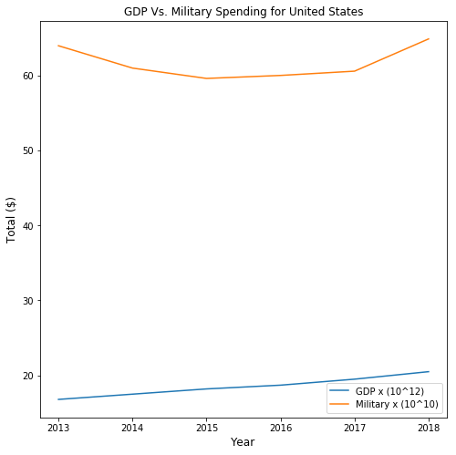

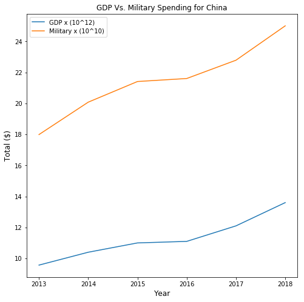

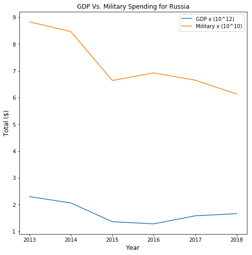

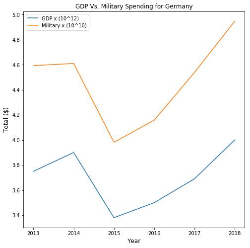

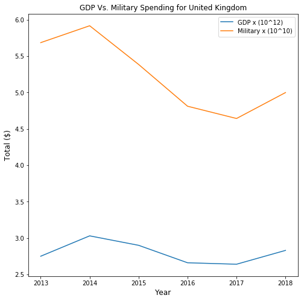

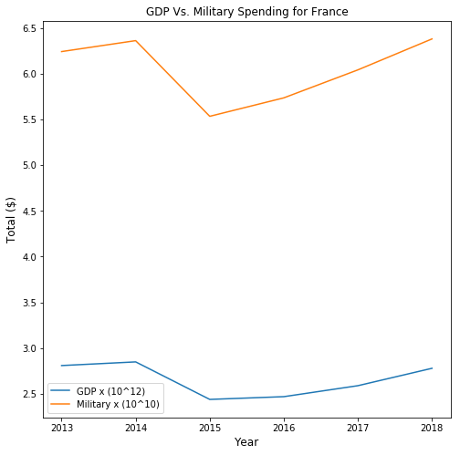

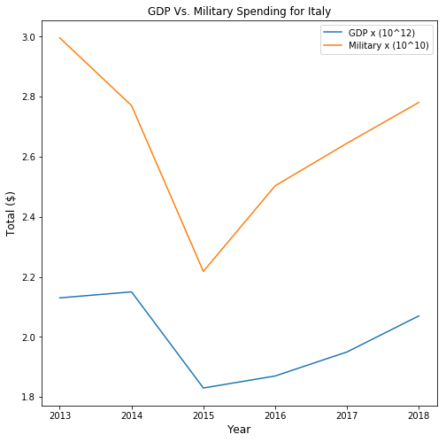

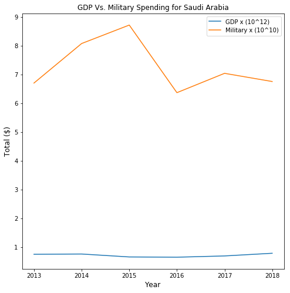

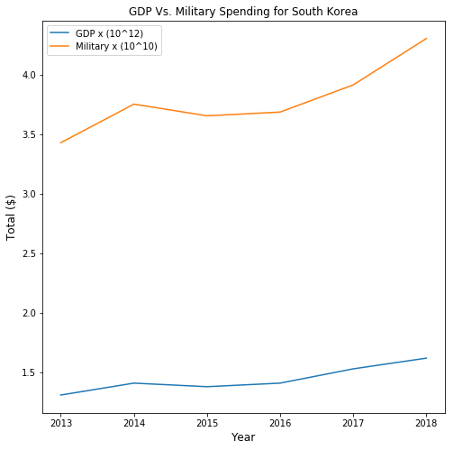

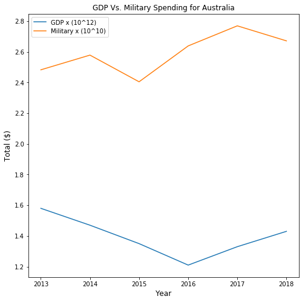

```python
# Create a for-loop using each country means that the plot will only need to be specified once, then they will be plotted automatically
places = ['United States', 'China', 'Russia', 'Germany', 'United Kingdom', 'France', 'Italy', 'Saudi Arabia', 'South Korea', 'Australia']

for p in places:
    plt.figure(figsize = (8,8))
    plot1(p, 'GDP x (10^12)')
    plot1(p, 'Military x (10^10)')
    plt.show()
```

The graphs show the GDP and Military spending for the 10 different countries from the year 2013 to 2018.

Overall, the GDP of the countries seem to be going up, but in 2014 & 2015 the GDP of the countries except the US, South Korea and China stagnated or declined, before recovering in 2016. Experts say that this could be due to the fact that GDP is measured in USD and the value of the dollar increased significantly between 2014 & 2015. This is evident when looking at the GDP of the EU countries. Saudi Arabia's GDP barely changed over the 5 year period.

Over the same period, the military spending pattern is almost identical to that displayed by the GDP for most of the countries analysed. This makes sense because as a country's GDP increases, there is more money to spend on sectors such as military. Again, there are some special cases such as Australia where the military spending is almost exactly opposite as GDP or in Saudi Arabia where the military spending seems to be greater than most countries even though they have the lowest GDP.

In general, the military spending and GDP are very strongly correlated.

## Comparing the overall military spending of all 10 countries

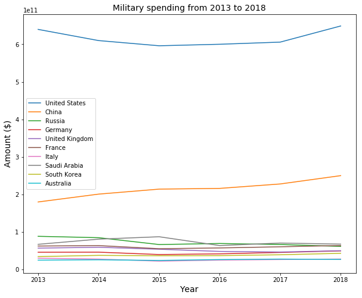

```python
# Create a loop to plot a graph for absolute military spending for all 10 countries between 2013 and 2018
places = ['United States', 'China', 'Russia', 'Germany', 'United Kingdom', 'France', 'Italy', 'Saudi Arabia', 'South Korea', 'Australia']

plt.figure(figsize=(10,8))

for p in places:
    data = countries.loc[p, 'Military']
    plt.plot(data.index, data.values, label = p)
    plt.legend(loc = 'best')
    plt.title('Military spending from 2013 to 2018', fontsize = 14)
    plt.ylabel('Amount ($)', fontsize = 14)
    plt.xlabel('Year', fontsize = 14)

plt.show()
```

The graph above shows the overall military spending per year for each country between the years of 2013 and 2018.

It is expected for the US to outspend every other country by a mile because the US has many military bases in every continent and tend to consider themselves the world police. China on the other hand, is becoming a world superpower; meaning they have increased budgets, which is reflected on military spending.

On the whole, countries dont seem to be spending more on military as the prospect of war is becoming less desirable and many countries have peace treaties with one another. This of course depends on who comes into power and what their views are.

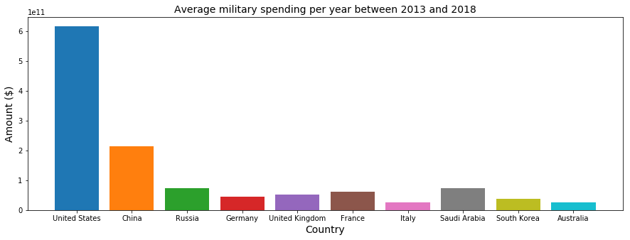

```python
# Import mean from the statistics library to be able to calculate the average spending per year for each country between 2013 & 2018 inclusive
from statistics import mean

# Create a loop to plot a graph for average military spending per year for all 10 countries between 2013 and 2018
places = ['United States', 'China', 'Russia', 'Germany', 'United Kingdom', 'France', 'Italy', 'Saudi Arabia', 'South Korea', 'Australia']

plt.figure(figsize=(15,5))

# Since we are looking at 1 value per country, it is much easier to visualise with a bar plot
for p in places:
    data = countries.loc[p, 'Military']
    mean_spending = mean(data)
    plt.bar(p, mean_spending)
    plt.title('Average military spending per year between 2013 and 2018', fontsize = 14)
    plt.xlabel('Country', fontsize = 14)
    plt.ylabel('Amount ($)', fontsize = 14)

plt.show()
```

The bar plot shows the average military spending per year between 2013 and 2018 for the 10 different countries.

The plot confirms that the United States outspends every other country by at least 2.5 times on the military per year on average. It also shows how China is the second biggest military spender on average. Every other country is more or less on par with one another; with Russia and Saudi Arabia spending slightly more on average than the rest. Italy and Australia are spending the least.

## Comparing the military spending per person to the GDP per capita

```python
# To compare the military spending per person to the GDP per capita, create a new column for military spending per person; which is simply Military Spending / Population
countries['Military Per Person'] = countries['Military'] / countries['Population']

# Create columns which reduce the military spending per person and GDP per capita to comparable scales
countries['Military Per Person x (10^3)'] = round((countries['Military'] / countries['Population']) / 1000, 2)
countries['Per Capita x (10^5)'] = countries['Per Capita'] / 100000
countries.head()
```

| Country Name |  | GDP | Per Capita | Population | Military | GDP x (10^12) | Military x (10^10) | Military Per Person | Military Per Person x (10^3) | Per Capita x (10^5) |
| --- | --- | --- | --- | --- | --- | --- | --- | --- | --- | --- |
| United States | 2013 | 1.680000e+13 | 53106.90977 | 316057727.0 | 6.397040e+11 | 16.8 | 63.9704 | 2024.010000 | 2.02 | 0.531069 |
|  | 2014 | 1.750000e+13 | 55032.95800 | 318386421.0 | 6.099140e+11 | 17.5 | 60.9914 | 1915.640743 | 1.92 | 0.550330 |
|  | 2015 | 1.820000e+13 | 56803.47243 | 320742673.0 | 5.961050e+11 | 18.2 | 59.6105 | 1858.514785 | 1.86 | 0.568035 |
|  | 2016 | 1.870000e+13 | 57904.20196 | 323071342.0 | 6.001060e+11 | 18.7 | 60.0106 | 1857.503040 | 1.86 | 0.579042 |
|  | 2017 | 1.950000e+13 | 59927.92983 | 325147121.0 | 6.058030e+11 | 19.5 | 60.5803 | 1863.165813 | 1.86 | 0.599279 |

```python
# Create a function to plot graphs for a specified country and dataset
# This function will be used to plot GDP per capita against military spending per person, so the title and axis labels are set accordingly
# Setting the line labels to the pertinent dataset, to insert a legend
def plot2(country, dataset):
    data = countries.loc[country, dataset]
    plt.plot(data.index, data.values, label = dataset)
    plt.legend()
    plt.title('GDP Per Capita Vs Military Spending Per Capita for ' + country)
    plt.xlabel('Year', fontsize = 12)
    plt.ylabel('Total ($)', fontsize = 12)
```

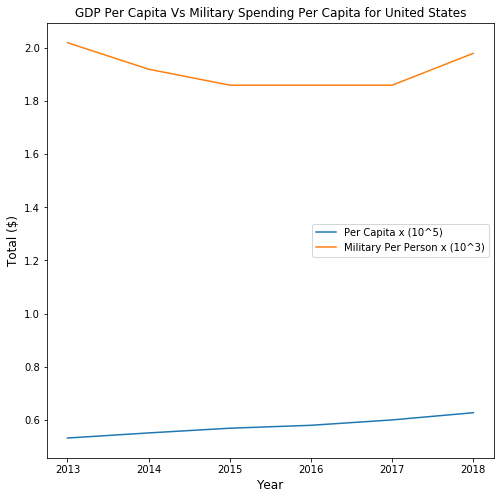

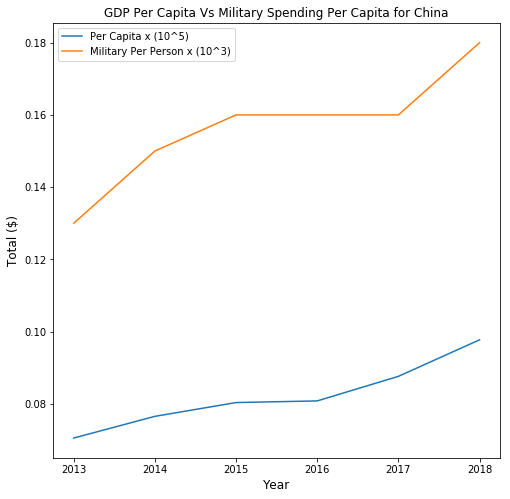

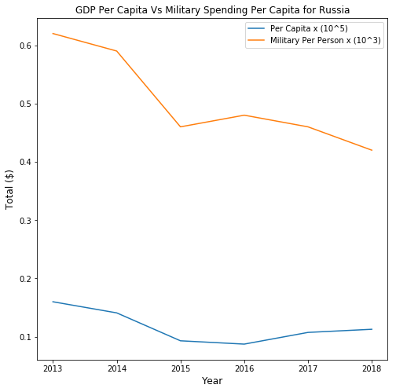

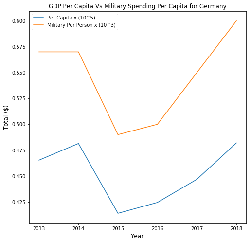

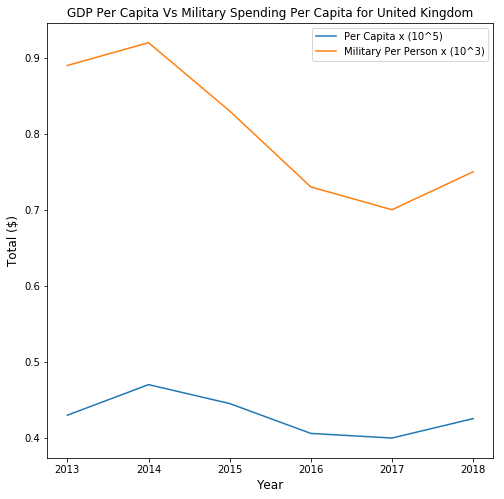

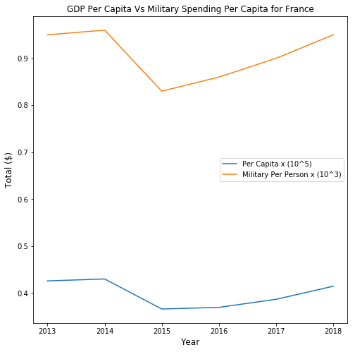

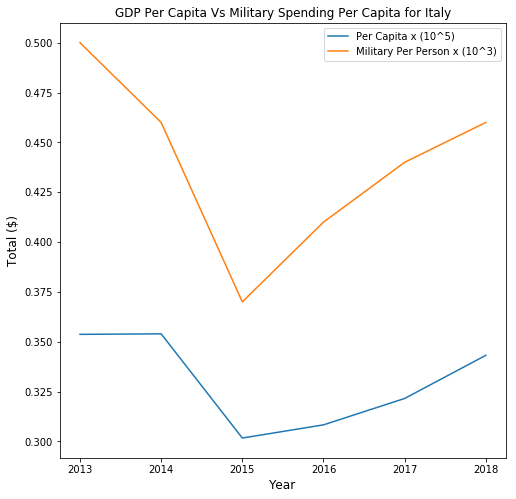

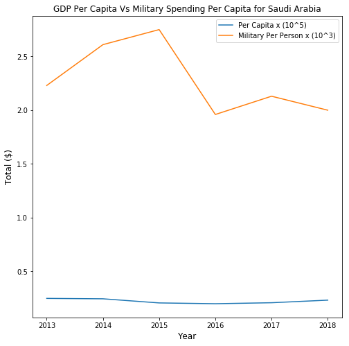

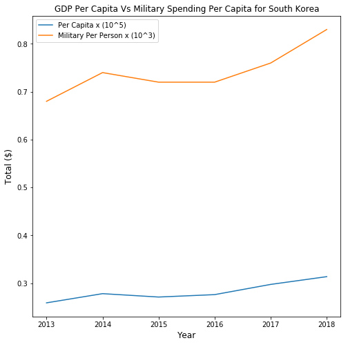

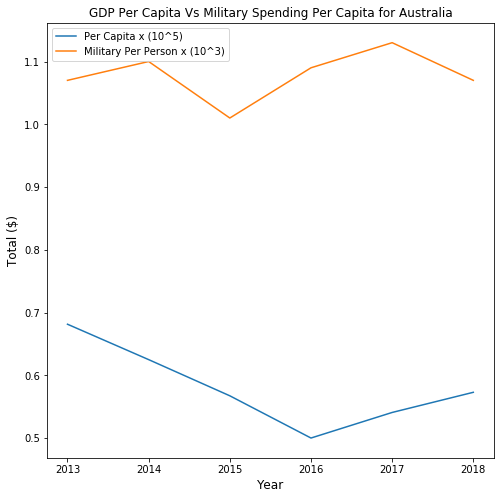

```python
# Create a for loop using each country means that the plot will only need to be specified once, then they will be plotted automatically
places = ['United States', 'China', 'Russia', 'Germany', 'United Kingdom', 'France', 'Italy', 'Saudi Arabia', 'South Korea', 'Australia']

for p in places:
    plt.figure(figsize = (8,8))
    plot2(p, 'Per Capita x (10^5)')
    plot2(p, 'Military Per Person x (10^3)')
    plt.show()
```

The graphs show the GDP per capita and military spending per person for the 10 different countries from the year 2013 to 2018.

Since GDP and GDP per capita are linked, the GDP per capita of the countries has an almost identical pattern to that of the GDP; where in general, GDP per capita is going up except for 2014 & 2015 before recovering in 2016 for reasons previously mentioned.

Over the same period, the military spending per capita follows a pattern almost identical to that displayed by the GDP per capita for most of the countries analysed. This makes sense because as a country's GDP per capita increases, there is more money to spend on sectors such as military. Again, there are some special cases such as Australia and Saudi Arabia where the military spending per capita has very little to no correlation with GDP per capita.

In general, the military spending per person and GDP per capita are strongly correlated.

```python
# To compare the military spending per person as a percentage of the GDP per capita, create a new column with the calculated percentage
countries['Military%'] = round((countries['Military Per Person'] / countries['Per Capita']) *100, 2)
countries.head()
```

| Country Name |  | GDP | Per Capita | Population | Military | GDP x (10^12) | Military x (10^10) | Military Per Person | Military Per Person x (10^3) | Per Capita x (10^5) | Military% |
| --- | --- | --- | --- | --- | --- | --- | --- | --- | --- | --- | --- |
| United States | 2013 | 1.680000e+13 | 53106.90977 | 316057727.0 | 6.397040e+11 | 16.8 | 63.9704 | 2024.010000 | 2.02 | 0.531069 | 3.81 |
|  | 2014 | 1.750000e+13 | 55032.95800 | 318386421.0 | 6.099140e+11 | 17.5 | 60.9914 | 1915.640743 | 1.92 | 0.550330 | 3.48 |
|  | 2015 | 1.820000e+13 | 56803.47243 | 320742673.0 | 5.961050e+11 | 18.2 | 59.6105 | 1858.514785 | 1.86 | 0.568035 | 3.27 |
|  | 2016 | 1.870000e+13 | 57904.20196 | 323071342.0 | 6.001060e+11 | 18.7 | 60.0106 | 1857.503040 | 1.86 | 0.579042 | 3.21 |
|  | 2017 | 1.950000e+13 | 59927.92983 | 325147121.0 | 6.058030e+11 | 19.5 | 60.5803 | 1863.165813 | 1.86 | 0.599279 | 3.11 |

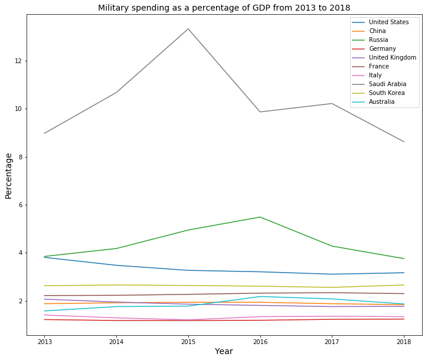

```python
# Create a loop to plot a graph for military spending per person as a percentage of GDP per capita for all 10 countries between 2013 and 2018
places = ['United States', 'China', 'Russia', 'Germany', 'United Kingdom', 'France', 'Italy', 'Saudi Arabia', 'South Korea', 'Australia']

plt.figure(figsize=(12,10))

for p in places:
    data = countries.loc[p, 'Military%']
    plt.plot(data.index, data.values, label = p)
    plt.legend()
    plt.title('Military spending as a percentage of GDP from 2013 to 2018', fontsize = 14)
    plt.xlabel('Year', fontsize = 14)
    plt.ylabel('Percentage', fontsize = 14)


plt.show()
```

The graph above shows the military spending per person as a percentage of GDP per capita per year for each country between the years of 2013 and 2018.

From the graph, it is clear to see that there is completely different story when it comes to how much percent is spent on military. In this case, Saudi Arabia spends the greatest percentage on military by a long way. The United States, who outspends every other country in absolute value, actually spends less than 4% per year from their GDP per capita on military; which does not seem as outrageous. China, who was the second biggest spender, spends a similar percentage of their GDP per capita as the lowest spending countries: This is probably because of the sheer population of China.

In terms of percentage, Russia is the second biggest spender, but has been decreasing since 2016 and is almost on par with the US. The other countries; which spend the least amount on military, also spend the least percentage.

On the whole, countries spend less than 5% of their GDP per capita on military. This is most likely because they are focusing their spending on other matters such as healthcare and the environment. This is also due to the fact that the prospect of war is becoming less desirable, but countries like Saudi Arabia who are in a war torn and hostile region, are forced to focus more of their budget on military spending.

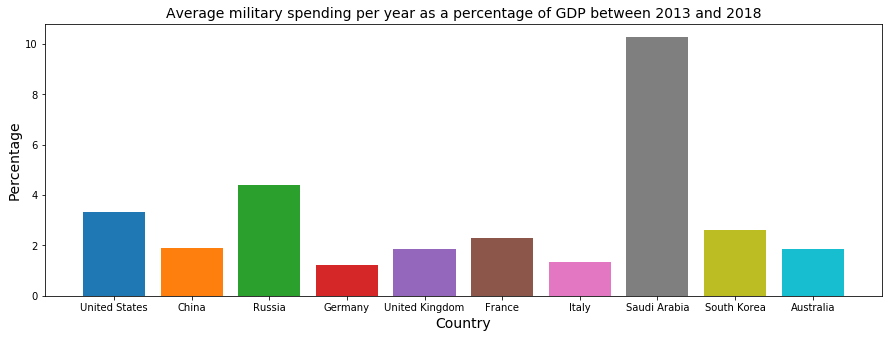

```python
# Create a loop to plot a graph for average military spending per year as a percentage of GDP per capita for all 10 countries between 2013 and 2018
places = ['United States', 'China', 'Russia', 'Germany', 'United Kingdom', 'France', 'Italy', 'Saudi Arabia', 'South Korea', 'Australia']

# Since we are looking at 1 value per country, it is much easier to visualise with a bar plot
plt.figure(figsize=(15,5))

for p in places:
    data = countries.loc[p, 'Military%']
    mean_pct = mean(data)
    plt.bar(p, mean_pct)
    plt.title('Average military spending per year as a percentage of GDP between 2013 and 2018', fontsize = 14)
    plt.ylabel('Percentage', fontsize = 14)
    plt.xlabel('Country', fontsize = 14)

plt.show()
```

The bar plot shows the average military spending per year as a percentage of GDP per capita between 2013 and 2018 for the 10 different countries.

The plot shows just how much more Saudi Arabia spend as a percentage on military than every outher country. It also shows that the United States, even though it outspends every other country by at least 2.5 times on military spending per year on average, the percentage of which actually goes to military is quite normal and almost on par with the other countries. It also shows how China, depsite being the second biggest military spender on average, also dedicates a very small percentage on military.

The other countries follow the trend that absolute military spending is correlated with military spending as a percentage of GDP per capita.

## Fastest growing countries in military spending

```python
# Create a new dataframe with just the military spending data (absolute)
military = pd.DataFrame(countries['Military'])
military.head()
```

| Country Name |  | Military |
| --- | --- | --- |
| United States | 2013 | 6.397040e+11 |
|  | 2014 | 6.099140e+11 |
|  | 2015 | 5.961050e+11 |
|  | 2016 | 6.001060e+11 |
|  | 2017 | 6.058030e+11 |

```python
# Calculate the absolute change and percentage change between years using the df.diff() and df.pct_change() functions
military['Change'] = military.diff()
military['Percentage Change'] = (military['Military'].pct_change())*100

# Since there is no data for 2012, drop 2013 for all countries as there will be no values
military = military.drop(index = '2013', level = 1)
military.head()
```

| Country Name |  | Military | Change | Percentage Change |
| --- | --- | --- | --- | --- |
| United States | 2014 | 6.099140e+11 | -2.979000e+10 | -4.656841 |
|  | 2015 | 5.961050e+11 | -1.380900e+10 | -2.264090 |
|  | 2016 | 6.001060e+11 | 4.001000e+09 | 0.671190 |
|  | 2017 | 6.058030e+11 | 5.697000e+09 | 0.949332 |
|  | 2018 | 6.487980e+11 | 4.299500e+10 | 7.097192 |

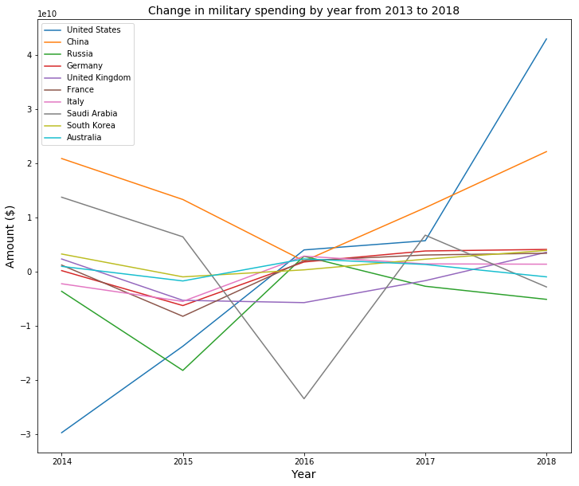

```python
# Create a loop to plot a graph for change in military spending per year for all 10 countries between 2014 and 2018
places = ['United States', 'China', 'Russia', 'Germany', 'United Kingdom', 'France', 'Italy', 'Saudi Arabia', 'South Korea', 'Australia']

plt.figure(figsize=(12,10))

for p in places:
    data = military.loc[p, 'Change']
    plt.plot(data.index, data.values, label = p)
    plt.legend()
    plt.title('Change in military spending by year from 2013 to 2018', fontsize = 14)
    plt.xlabel('Year', fontsize = 14)
    plt.ylabel('Amount ($)', fontsize = 14)

plt.show()
```

The graph shows the change in military spending each year between 2014 and 2018 for all 10 countries. 2013 was not included as there is no data for the change in that year.

The graph shows that the military spending for the majority of countries changes by less than 10 Billion USD per year.

From this graph, it shows there is a correlation that the countries which spend the most on military, tend to make the biggest increases on military spending per year.

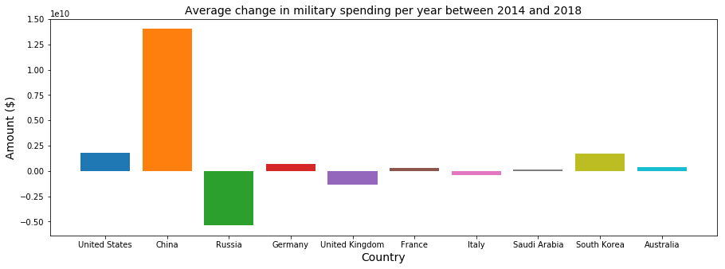

```python
# Create a loop to plot a bar graph for average change in military spending per year for all 10 countries between 2014 and 2018
places = ['United States', 'China', 'Russia', 'Germany', 'United Kingdom', 'France', 'Italy', 'Saudi Arabia', 'South Korea', 'Australia']

# Since we are looking at 1 value per country, it is much easier to visualise with a bar plot
plt.figure(figsize=(15,5))

for p in places:
    data = military.loc[p, 'Change']
    mean_c = mean(data)
    plt.bar(p, mean_c)
    plt.title('Average change in military spending per year between 2014 and 2018', fontsize = 14)
    plt.ylabel('Amount ($)', fontsize = 14)
    plt.xlabel('Country', fontsize = 14)

plt.show()
```

This bar plot shows the average change in military spending each year between 2014 and 2018 for all 10 countries. 2013 was not included as there is no data for the change in that year.

This plot shows that over the past 5 years, China's military has been growing by approximately 10x more than the other countries in absolute spending. The US's military spending is also growing, but at a much slower rate. The biggest surprise is the fact that out of the 10 countries, South Korea's army has been growing the third fastest on average in absolute spending over the past 5 years.

Even though Saudi Arabia was spending the most percent of their GDP on military, their military spending has had almost no increase on average in the past 5 years. This is because Saudi Arabia spends a similar amount to many of the countries, despite their GDP being the lowest.

When it comes to average increase in military spending per year, China is the stand-out country as they spend on average, almost 15 Billion more each year on military than the previous.

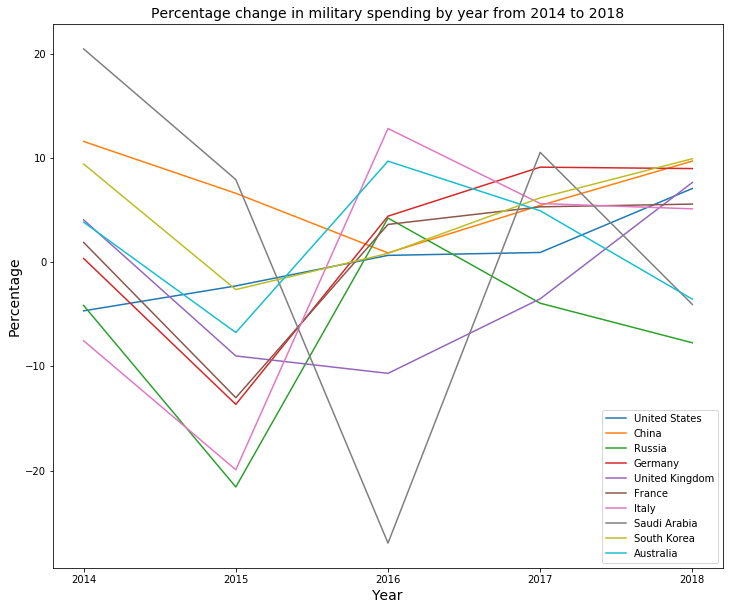

```python
# Create a loop to plot a graph for percentage change in military spending per year for all 10 countries between 2014 and 2018
places = ['United States', 'China', 'Russia', 'Germany', 'United Kingdom', 'France', 'Italy', 'Saudi Arabia', 'South Korea', 'Australia']

plt.figure(figsize=(12,10))

for p in places:
    data = military.loc[p, 'Percentage Change']
    plt.plot(data.index, data.values, label = p)
    plt.legend()
    plt.title('Percentage change in military spending by year from 2014 to 2018', fontsize = 14)
    plt.xlabel('Year', fontsize = 14)
    plt.ylabel('Percentage', fontsize = 14)

plt.show()
```

The graph shows the percentage change in military spending each year between 2014 and 2018 for all 10 countries. 2013 was not included as there is no data for the change in that year.

The graph shows that the percentage change in military spending varies a lot for most of the countries; with Saudi Arabia having the most extreme changes per year.

Three out of the 4 countries who are spending more on the military, were in the top three for the biggest military growth in absolute spending on average since 2013.

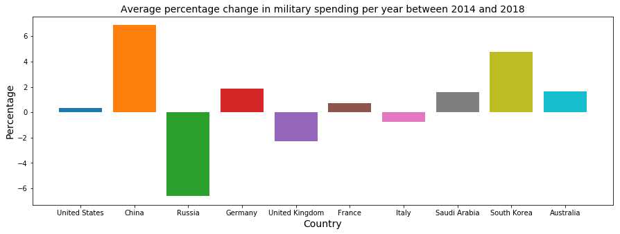

```python
# Create a loop to plot a bar graph for average percentage change in military spending per year for all 10 countries between 2014 and 2018
places = ['United States', 'China', 'Russia', 'Germany', 'United Kingdom', 'France', 'Italy', 'Saudi Arabia', 'South Korea', 'Australia']

# Since we are looking at 1 value per country, it is much easier to visualise with a bar plot
plt.figure(figsize=(15,5))

for p in places:
    data = military.loc[p, 'Percentage Change']
    mean_p = mean(data)
    plt.bar(p, mean_p)
    plt.title('Average percentage change in military spending per year between 2014 and 2018', fontsize = 14)
    plt.ylabel('Percentage', fontsize = 14)
    plt.xlabel('Country', fontsize = 14)

plt.show()
```

This bar plot shows the average change in military spending each year between 2014 and 2018 for all 10 countries. 2013 was not included as there is no data for the change in that year.

This plot shows that over the past 5 years, China's military has been growing by at the highest rate in terms of percentage. Suprisingly, the US has had a very little percentage increase on average since 2013; which is contrary to instinct since they outspend every other country and have one of the highest GDPs. Again, South Korea is expanding their military forces at a fast rate, this time being the second fastest for average percentage increase per year. The next biggest expanding militaries belong to Germany, Saudi Arabia and Australia; which have all increased their military spending by an average of about 2% a year since 2013.

Russia, the UK and Italy are the only countries which have decreased their military spending per year on average since 2013, with Russia being the country whose military spending has decreased the most.

## Predictions

From the data gathered and the graphs plotted, there are clear patterns which can be observed. These patterns do not just show what is happening or what has happened; they also serve as an indicator for the future, allowing for predictions to be made based on these patterns.

Since GDP usually increseases from year to year, especially in developed countries, I believe that military spending will follow what GDP does and also keep increasing: The main reason being that if a country's GDP increases, it has more money to spend on sectors like military. Countries will continue to invest in the military in the near future because of the war on terror and as a precaution for another world war. Countries like the US spend great amounts on military to act as a deterrent and try to keep the peace. Spending also increases because the technology in military applications is getting more complex, therefore gets more expensive.

I believe countries from the EU and Australia will decrease their spending habits slighly because there is not much threat to them. In the case of the EU, the countries are an alliance and they are moving more towards having a general EU army; which means countries are contributing to a general army rather than investing in their own.

Other factors like climate change will cause countries to eventually focus more of their spending on saving our planet, so even though military spending will stay the same or even go up slightly, I think that over time the military spending as a percentage of GDP will start to decrease; especially in first world countries.

On the whole, I predict that military spending will keep going up in the near future as GDP keeps going up; but the percentage of which is spent on military will start to level out and decrease as countries focus their attention on other issues.

## Learning Process

Throughout this project, I have developed my current python skills and learnt new features which make data mining more efficient. I have learnt functions such as stack() or concat() to change the structure of a dataframe and combine numerous dataframes into one. I have become more familiar with functions and loops; using them to create mulitple plots efficiently whilst making them well labelled and easy to read. My data interpretation has improved as I have had to interepret data from multiple graphs and spot patterns/correlations which may be present.

Apart from the coding aspect, I feel like I can interpret data plots with more knowledge and be more deliberate about the data I need and how the questions being asked relates to the data plots being created. I have also started using the plots I create, along with my personal knowledge to make predictions based on the current trends and correlations.

Overall, my data mining, data visualization and coding skills have greatly improved thanks to this project.

## Conclusion

From the data gathered and plots created, there are a few conclusions which can be made.

In general, the military spending of a country is strongly correlated with the GDP of the country; so as the GDP of a country increases, the military spending tends to do the same. When it comes to overall spending on average, the US is way above every other country and China is comfortably in second. The rest of the countries spend more or less the same on military. In terms of military spending as a percentage of GDP, Saudi Arabia spends on average around 10% of their GDP per capita on military; which is far greater than the other countries.

China is clearly the fastest growing military; both in terms of average spending increase per year and average percentage increase per year. Suprisingly, South Korea is Second; which is unexpected from the data provided. On the other hand, Russia is the fastest shrinking military with an average decrease of 6% percent since 2013. Even though the US spends more than the other countries per year combined, their spending as a percentage of GDP is very reasonable and their average spending per year since 2013 has barely increased.

Overall, countries which are more likely to go to war due to their geographic locations or their beliefs are spending more on military. Countries which form part of large unions such as the European Countries, or are more secluded like Australia are spending less on military.